Created by: Marco Hafid - 22-620-546 Matus Kubla - 23-604-382

In this problem set, we aim to implement the AdaBoost algorithm on stumps to perform email spam classification. The dataset used contains 4601 observations with 57 features and two class labels:

1 - Spam (~40% of observations) 0 – Not spam (~60% of observations)

The 57 features may be summarized as follows: - 48 measure specific word frequencies and - 6 measure specific character frequencies in the email. - 1 measures the average length of uninterrupted sequences of capital letters - 1 measures the length of the longest length of uninterrupted sequences of capital letters - 1 measures the total number of capital letters in the email

The dataset is separated into a training and test sample based on an available indicator dataset (1 - testing sample | 0 - training sample)

```r
suppressWarnings({
# Importing the libraries
library(rpart)
library(caret)
library(kableExtra)
library(ggplot2)
library(knitr)
})
```

DATA PREPARATION:

We use the provided spam.data and spam.traintest datasets. We read in both datasets and update the class labels from 0 to -1, to fit with our task.

```r
# Importing the data
data <- read.table("spam.data", header = FALSE, sep = "", fill = TRUE)
train <- read.table("spam.traintest", header = FALSE)

# Combine the datasets
data_full <- cbind(data, train)
colnames(data_full)[ncol(data_full)] <- "indicator"

# Convert class labels: 0 to -1 for spam classification
data_full[, ncol(data_full)-1] <- ifelse(data_full[, ncol(data_full)-1] == 0, -1, 1)
```

While spam.data contains the whole dataset, we use the indicators in the spam.traintest file to separate the dataset into a training and testing sample. These are then further separated into features and outputs (the class we want to specify) for both.

```r
# Split the data based on the indicator
test_sample <- subset(data_full, indicator == 1, select = -indicator)
training_sample <- subset(data_full, indicator == 0, select = -indicator)

# Prepare the data into test and training samples
X_train <- training_sample[, -ncol(training_sample)]
Y_train <- training_sample[, ncol(training_sample)]
X_test <- test_sample[, -ncol(test_sample)]
Y_test <- test_sample[, ncol(test_sample)]
```

GENERAL APPROACH:

To perform our analysis, we first define week learners – stumps – simple, one-depth decision trees with a single split.

For each step of the AdaBoost algorithm, we find a new, „best“ week learner (stump), which minimizes the weighted empirical risk. To do this, for each iteration of the algorithm, we iterate over all features, possible split points, and direction choices, to identify the stump that leads to the smallest error, (given by the sum of misclassified instances).

After selecting a new stump for an iteration, the AdaBoost algorithm will update the weights of the training instances in the following manner: - misclassified instances have their weights increased - correctly classified stumps have their weights decreased This allows the algorithm to focus on those instances that were harder to classify previously, gradually „filling in the gaps“ and hence improving performance (and also assuring that the same stump is not selected in each iteration).

Due to the nature of the classification task, we will later adapt our algorithm in an attempt to specifically reduce the FPR (False Positive Rate). More concretely, our motivation stems from the fact that in classifying spam emails, wrongfully designating an email as spam has considerably higher negative implications than failing to correctly identify a spam email.

More specifically, we implement a possibility to specify between a standard and FPR adapted approach in the AdaBoost function input. In the FPR adjusted version, we aim to put a stronger emphasis on minimizing FPR by increasing the weight of false positive mislassifications. This should push the model to address this issue in further iterations, and ideally, improve performance in this metric.

```r
# Define the Stump function
stump <- function(X, Y, W) {
  best_split <- NULL
  best_feature <- NULL
  best_error <- Inf
  best_direction <- NULL
  for(j in 1:ncol(X)) {
    for(split in unique(X[, j])) {
      for(direction in c(-1, 1)) {
        prediction <- ifelse(X[, j] < split, direction, -direction)
        error <- sum(W * (prediction != Y))
        if(error < best_error) {
          best_error <- error
          best_split <- split
          best_feature <- j
          best_direction <- direction
        }
      }
    }
  }
  list(split = best_split, feature = best_feature, direction = best_direction, error = best_error)
}

# Define the adaboost function
adaBoost <- function(X, Y, M, apply_fpr_adjustment = FALSE, initial_model = NULL) {
  n <- nrow(X)
  # Use initial weights, classifiers, alpha values if an initial model is provided
  W <- if (is.null(initial_model)) rep(1/n, n) else initial_model$W
  classifiers <- if (is.null(initial_model)) list() else initial_model$classifiers
  alpha <- if (is.null(initial_model)) numeric(M) else initial_model$alpha
  feature_importance <- if (is.null(initial_model)) rep(0, ncol(X)) else initial_model$feature_importance
  feature_count <- if (is.null(initial_model)) rep(0, ncol(X)) else initial_model$feature_count
  start_m <- length(classifiers) + 1 # Determine the starting point based on the initial model
  for(m in start_m:M) {
    stump_result <- stump(X, Y, W)
    prediction <- ifelse(X[, stump_result$feature] < stump_result$split, stump_result$direction, -stump_result$direction)
    # Error calculation, potentially adjusted for FPR
    err <- sum(W * (prediction != Y)) / sum(W)
    if(apply_fpr_adjustment) {
      # Identify false positives and adjust weights
      is_false_positive <- (prediction == 1) & (Y == -1) # Assuming Y is -1 for negative class
      # Increase weight for false positives
      W[is_false_positive] <- W[is_false_positive] * 2
      # Recalculate error after adjusting weights for false positives
      err <- sum(W * (prediction != Y)) / sum(W)
    }
    alpha_m <- log((1 - err) / err) / 2
    W <- W * exp(-alpha_m * prediction * Y)
    W <- W / sum(W) # Normalize weights after adjustment
    classifiers <- c(classifiers, list(list(split = stump_result$split, feature = stump_result$feature, direction = stump_result$direction, alpha = alpha_m)))
    feature_importance[stump_result$feature] <- feature_importance[stump_result$feature] + alpha_m
    feature_count[stump_result$feature] <- feature_count[stump_result$feature] + 1
  }
  list(W = W, classifiers = classifiers, alpha = alpha, feature_importance = feature_importance, feature_count = feature_count, predict = function(X) {
    final_scores <- numeric(nrow(X))
    for(classifier in classifiers) {
      prediction <- ifelse(X[, classifier$feature] < classifier$split, classifier$direction, -classifier$direction)
      final_scores <- final_scores + classifier$alpha * prediction
    }
    sign(final_scores)
  })
}
```

To implement our code more efficiently, we store the results of our models as we increase iteration steps (and hence the number of stumps used). Instead of looping through all the possibilities with each new test, our algorithm is hence able to access the procedure of the preceding ones, picking up where the last one left off.

```r
# Define the runanalysis function
runAnalysis <- function(X_train, Y_train, X_test, Y_test, M_values, apply_fpr_adjustment) {
  metrics_list <- list()
  models_list <- list()
  last_model <- NULL

  # Ensure M_values is sorted to incrementally increase the number of stumps
  M_values <- sort(unique(M_values))

  for (M in M_values) {
    # If there is a last_model, use it as the starting point for further training
    if (!is.null(last_model)) {
      ada_model <- adaBoost(X_train, Y_train, M, apply_fpr_adjustment, last_model)
    } else {
      ada_model <- adaBoost(X_train, Y_train, M, apply_fpr_adjustment)
    }

    # Update last_model with the newly trained model
    last_model <- ada_model

    predictions <- ada_model$predict(X_test)
    conf_matrix <- confusionMatrix(as.factor(predictions), as.factor(Y_test))
    test_error <- mean(predictions != Y_test)

    metrics_list[[as.character(M)]] <- list(
      M = M,
      TestError = test_error,
      Accuracy = conf_matrix$overall['Accuracy'],
      Precision = conf_matrix$byClass['Precision'],
      Recall = conf_matrix$byClass['Recall'],
      F1 = conf_matrix$byClass['F1'],
      FPR = conf_matrix$table[1,2] / (conf_matrix$table[1,2] + conf_matrix$table[1,1])
    )
    models_list[[as.character(M)]] <- ada_model
  }

  metrics_df <- do.call(rbind, lapply(metrics_list, function(x) as.data.frame(t(unlist(x)), stringsAsFactors = FALSE)))
  rownames(metrics_df) <- NULL
  metrics_df <- data.frame(lapply(metrics_df, function(x) as.numeric(as.character(x))), stringsAsFactors = FALSE)
  colnames(metrics_df) <- c("M", "TestError", "Accuracy", "Precision", "Recall", "F1", "FPR")
  return(list(metrics_df = metrics_df, models_list = models_list))
}
```

```r
# Define a vector of different M values
M_values <- c(1,5,10,25,50,100)

# Run the analysis without FPR adjustment
analysis_results_without_fpr <- runAnalysis(X_train, Y_train, X_test, Y_test, M_values, FALSE)

# Run the analysis with FPR adjustment
analysis_results_with_fpr <- runAnalysis(X_train, Y_train, X_test, Y_test, M_values, TRUE)
```

```r
# Metrics and Plots for the analysis without FPR adjustment
metrics_df_without_fpr <- analysis_results_without_fpr$metrics_df

# Display metrics using knitr::kable for the analysis without FPR adjustment
kable_output_without_fpr <- knitr::kable(metrics_df_without_fpr, format = "html", caption = "Performance Metrics without FPR Adjustment") %>%
  kableExtra::kable_styling(bootstrap_options = c("striped", "hover")) %>%
  kableExtra::column_spec(1, bold = TRUE, color = "white", background = "#0073C2") %>%
  kableExtra::column_spec(2:7, background = "#E7E6E6")
print(kable_output_without_fpr)
```

```
## <table class="table table-striped table-hover" style="margin-left: auto; margin-right: auto;">
## <caption>Performance Metrics without FPR Adjustment</caption>
##  <thead>
##   <tr>
##    <th style="text-align:right;"> M </th>
##    <th style="text-align:right;"> TestError </th>
##    <th style="text-align:right;"> Accuracy </th>
##    <th style="text-align:right;"> Precision </th>
##    <th style="text-align:right;"> Recall </th>
##    <th style="text-align:right;"> F1 </th>
##    <th style="text-align:right;"> FPR </th>
##   </tr>
##  </thead>
## <tbody>
##   <tr>
##    <td style="text-align:right;font-weight: bold;color: white !important;background-color: rgba(0, 115, 194, 255) !important;"> 1 </td>
##    <td style="text-align:right;background-color: rgba(231, 230, 230, 255) !important;"> 0.2141927 </td>
##    <td style="text-align:right;background-color: rgba(231, 230, 230, 255) !important;"> 0.7858073 </td>
##    <td style="text-align:right;background-color: rgba(231, 230, 230, 255) !important;"> 0.7633391 </td>
##    <td style="text-align:right;background-color: rgba(231, 230, 230, 255) !important;"> 0.9426142 </td>
##    <td style="text-align:right;background-color: rgba(231, 230, 230, 255) !important;"> 0.8435568 </td>
##    <td style="text-align:right;background-color: rgba(231, 230, 230, 255) !important;"> 0.2366609 </td>
##   </tr>
##   <tr>
##    <td style="text-align:right;font-weight: bold;color: white !important;background-color: rgba(0, 115, 194, 255) !important;"> 5 </td>
##    <td style="text-align:right;background-color: rgba(231, 230, 230, 255) !important;"> 0.1002604 </td>
##    <td style="text-align:right;background-color: rgba(231, 230, 230, 255) !important;"> 0.8997396 </td>
##    <td style="text-align:right;background-color: rgba(231, 230, 230, 255) !important;"> 0.9111808 </td>
##    <td style="text-align:right;background-color: rgba(231, 230, 230, 255) !important;"> 0.9266738 </td>
##    <td style="text-align:right;background-color: rgba(231, 230, 230, 255) !important;"> 0.9188620 </td>
##    <td style="text-align:right;background-color: rgba(231, 230, 230, 255) !important;"> 0.0888192 </td>
##   </tr>
##   <tr>
##    <td style="text-align:right;font-weight: bold;color: white !important;background-color: rgba(0, 115, 194, 255) !important;"> 10 </td>
##    <td style="text-align:right;background-color: rgba(231, 230, 230, 255) !important;"> 0.1035156 </td>
##    <td style="text-align:right;background-color: rgba(231, 230, 230, 255) !important;"> 0.8964844 </td>
##    <td style="text-align:right;background-color: rgba(231, 230, 230, 255) !important;"> 0.8871287 </td>
##    <td style="text-align:right;background-color: rgba(231, 230, 230, 255) !important;"> 0.9521785 </td>
##    <td style="text-align:right;background-color: rgba(231, 230, 230, 255) !important;"> 0.9185033 </td>
##    <td style="text-align:right;background-color: rgba(231, 230, 230, 255) !important;"> 0.1128713 </td>
```

[output cut: 15 more lines]

```
##    <td style="text-align:right;background-color: rgba(231, 230, 230, 255) !important;"> 0.9628055 </td>
##    <td style="text-align:right;background-color: rgba(231, 230, 230, 255) !important;"> 0.9467085 </td>
##    <td style="text-align:right;background-color: rgba(231, 230, 230, 255) !important;"> 0.0688592 </td>
##   </tr>
##   <tr>
##    <td style="text-align:right;font-weight: bold;color: white !important;background-color: rgba(0, 115, 194, 255) !important;"> 100 </td>
##    <td style="text-align:right;background-color: rgba(231, 230, 230, 255) !important;"> 0.0559896 </td>
##    <td style="text-align:right;background-color: rgba(231, 230, 230, 255) !important;"> 0.9440104 </td>
##    <td style="text-align:right;background-color: rgba(231, 230, 230, 255) !important;"> 0.9476440 </td>
##    <td style="text-align:right;background-color: rgba(231, 230, 230, 255) !important;"> 0.9617428 </td>
##    <td style="text-align:right;background-color: rgba(231, 230, 230, 255) !important;"> 0.9546414 </td>
##    <td style="text-align:right;background-color: rgba(231, 230, 230, 255) !important;"> 0.0523560 </td>
##   </tr>
## </tbody>
## </table>
```

```r
# Repeat the process for the analysis with FPR adjustment
metrics_df_with_fpr <- analysis_results_with_fpr$metrics_df

# Display metrics using knitr::kable for the analysis with FPR adjustment
kable_output_with_fpr <- knitr::kable(metrics_df_with_fpr, format = "html", caption = "Performance Metrics with FPR Adjustment") %>%
  kableExtra::kable_styling(bootstrap_options = c("striped", "hover")) %>%
  kableExtra::column_spec(1, bold = TRUE, color = "white", background = "#4CAF50") %>%
  kableExtra::column_spec(2:7, background = "#E8F5E9")
print(kable_output_with_fpr)
```

```
## <table class="table table-striped table-hover" style="margin-left: auto; margin-right: auto;">
## <caption>Performance Metrics with FPR Adjustment</caption>
##  <thead>
##   <tr>
##    <th style="text-align:right;"> M </th>
##    <th style="text-align:right;"> TestError </th>
##    <th style="text-align:right;"> Accuracy </th>
##    <th style="text-align:right;"> Precision </th>
##    <th style="text-align:right;"> Recall </th>
##    <th style="text-align:right;"> F1 </th>
##    <th style="text-align:right;"> FPR </th>
##   </tr>
##  </thead>
## <tbody>
##   <tr>
##    <td style="text-align:right;font-weight: bold;color: white !important;background-color: rgba(76, 175, 80, 255) !important;"> 1 </td>
##    <td style="text-align:right;background-color: rgba(232, 245, 233, 255) !important;"> 0.2141927 </td>
##    <td style="text-align:right;background-color: rgba(232, 245, 233, 255) !important;"> 0.7858073 </td>
##    <td style="text-align:right;background-color: rgba(232, 245, 233, 255) !important;"> 0.7633391 </td>
##    <td style="text-align:right;background-color: rgba(232, 245, 233, 255) !important;"> 0.9426142 </td>
##    <td style="text-align:right;background-color: rgba(232, 245, 233, 255) !important;"> 0.8435568 </td>
##    <td style="text-align:right;background-color: rgba(232, 245, 233, 255) !important;"> 0.2366609 </td>
##   </tr>
##   <tr>
##    <td style="text-align:right;font-weight: bold;color: white !important;background-color: rgba(76, 175, 80, 255) !important;"> 5 </td>
##    <td style="text-align:right;background-color: rgba(232, 245, 233, 255) !important;"> 0.1764323 </td>
##    <td style="text-align:right;background-color: rgba(232, 245, 233, 255) !important;"> 0.8235677 </td>
##    <td style="text-align:right;background-color: rgba(232, 245, 233, 255) !important;"> 0.7863248 </td>
##    <td style="text-align:right;background-color: rgba(232, 245, 233, 255) !important;"> 0.9776833 </td>
##    <td style="text-align:right;background-color: rgba(232, 245, 233, 255) !important;"> 0.8716248 </td>
##    <td style="text-align:right;background-color: rgba(232, 245, 233, 255) !important;"> 0.2136752 </td>
##   </tr>
##   <tr>
##    <td style="text-align:right;font-weight: bold;color: white !important;background-color: rgba(76, 175, 80, 255) !important;"> 10 </td>
##    <td style="text-align:right;background-color: rgba(232, 245, 233, 255) !important;"> 0.2207031 </td>
##    <td style="text-align:right;background-color: rgba(232, 245, 233, 255) !important;"> 0.7792969 </td>
##    <td style="text-align:right;background-color: rgba(232, 245, 233, 255) !important;"> 0.7366352 </td>
##    <td style="text-align:right;background-color: rgba(232, 245, 233, 255) !important;"> 0.9957492 </td>
##    <td style="text-align:right;background-color: rgba(232, 245, 233, 255) !important;"> 0.8468143 </td>
##    <td style="text-align:right;background-color: rgba(232, 245, 233, 255) !important;"> 0.2633648 </td>
```

[output cut: 15 more lines]

```
##    <td style="text-align:right;background-color: rgba(232, 245, 233, 255) !important;"> 1.0000000 </td>
##    <td style="text-align:right;background-color: rgba(232, 245, 233, 255) !important;"> 0.7597901 </td>
##    <td style="text-align:right;background-color: rgba(232, 245, 233, 255) !important;"> 0.3873698 </td>
##   </tr>
##   <tr>
##    <td style="text-align:right;font-weight: bold;color: white !important;background-color: rgba(76, 175, 80, 255) !important;"> 100 </td>
##    <td style="text-align:right;background-color: rgba(232, 245, 233, 255) !important;"> 0.3873698 </td>
##    <td style="text-align:right;background-color: rgba(232, 245, 233, 255) !important;"> 0.6126302 </td>
##    <td style="text-align:right;background-color: rgba(232, 245, 233, 255) !important;"> 0.6126302 </td>
##    <td style="text-align:right;background-color: rgba(232, 245, 233, 255) !important;"> 1.0000000 </td>
##    <td style="text-align:right;background-color: rgba(232, 245, 233, 255) !important;"> 0.7597901 </td>
##    <td style="text-align:right;background-color: rgba(232, 245, 233, 255) !important;"> 0.3873698 </td>
##   </tr>
## </tbody>
## </table>
```

We summarize our results above. As can be clearly seen, there is a considerable difference between the results for both methods - standard, and artificially adjusted In the standard version, we primarily see a progressive improvement in performance across all metrics as M increases. This makes intuitive sense, as aggregating more week learners should, in theory, lead to stringer,more comprehensive decision-making ability, and hence better estimates. That said, an interesting observation happens between M = 5 and M = 10, with the former yielding better results, for which the reason remained unclear to us. Moreover, a potentially surprising result was that even a single stump, if chosen optimally, yielded an accuracy of almost 80%, which is considerable for so simple of a decision rule.

We continue our analysis of results through graphical visualizations.

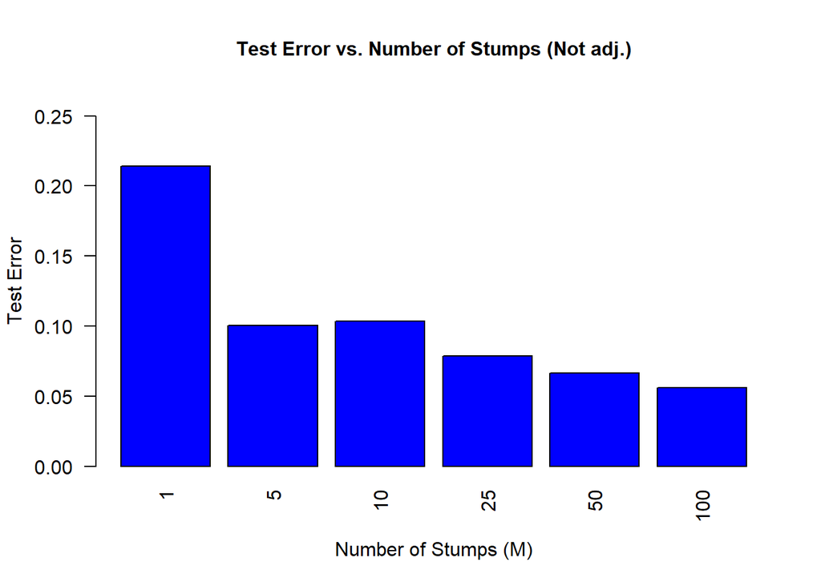

```r
# Plot test errors as a bar graph without FPR adjustment
barplot(metrics_df_without_fpr$TestError, names.arg = metrics_df_without_fpr$M, las = 2, col = 'blue',
        main = "Test Error vs. Number of Stumps (Not adj.)", xlab = "Number of Stumps (M)",
        ylab = "Test Error", ylim = c(0, max(metrics_df_without_fpr$TestError) + 0.05), cex.main = 1)
```

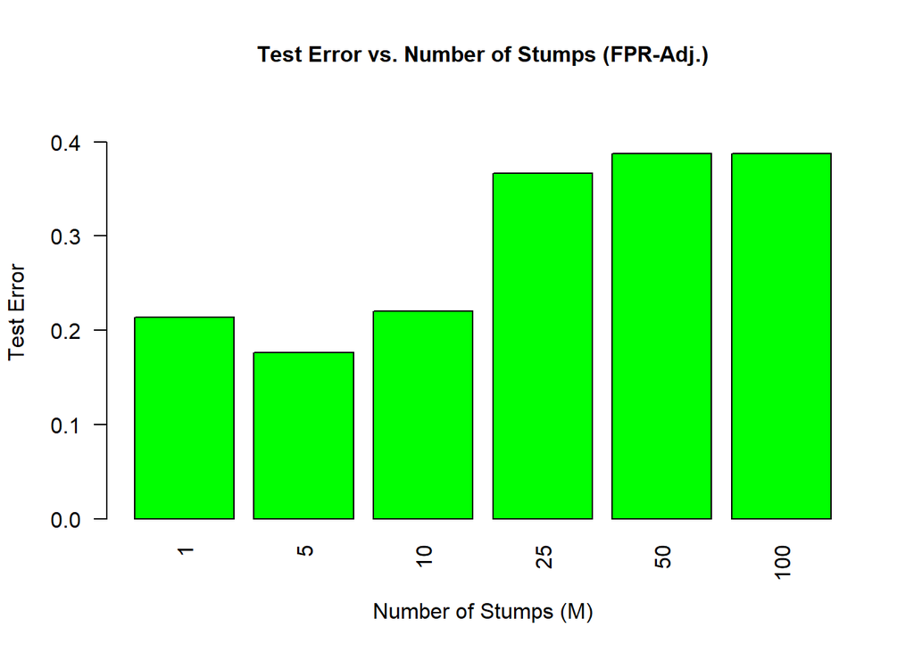

```r
# Plot test errors as a bar graph with FPR adjustment
barplot(metrics_df_with_fpr$TestError, names.arg = metrics_df_with_fpr$M, las = 2, col = 'green',
        main = "Test Error vs. Number of Stumps (FPR-Adj.)", xlab = "Number of Stumps (M)",
        ylab = "Test Error", ylim = c(0, max(metrics_df_with_fpr$TestError) + 0.05), cex.main = 1)
```

The above graph plots the evolution of the test error - the proportion of incorrect classifications made overall - across increasing values of M. As previously discussed, we see a clear down trend for the standard AdaBoost algorithm as M increases, while the FPR adjusted one suffers the opposite fate as M grows larger than 5.

In the following and final part, we provide a comprehensive overview of the feature importance and count throughout the two algorithms. Mainly, the code provides a graphical representation of both how much each of the features contribute to the model’s accuracy, and how often a feature is chosen as the feature to be split on.

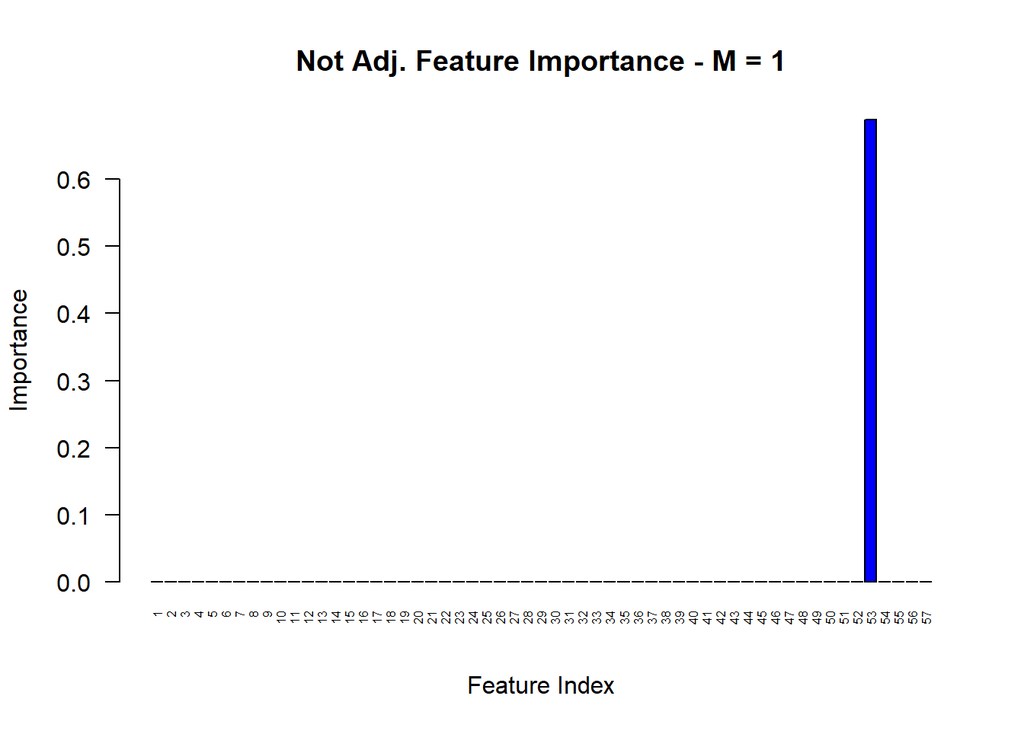

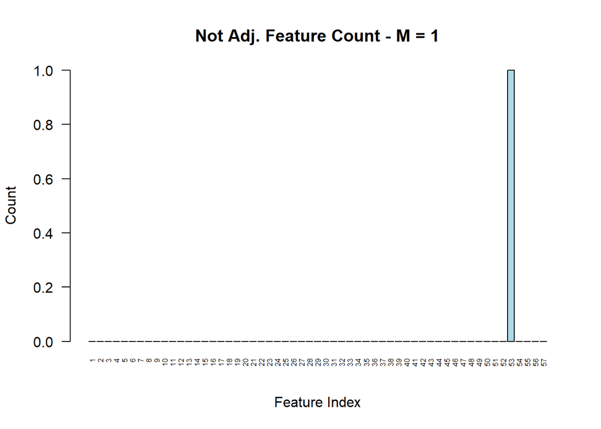

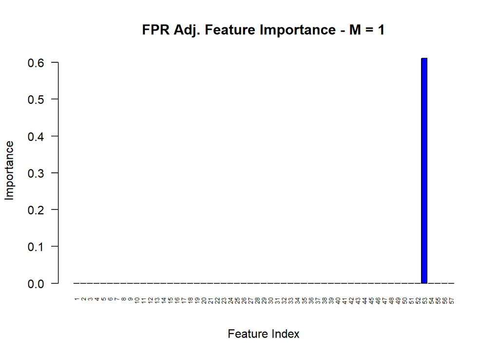

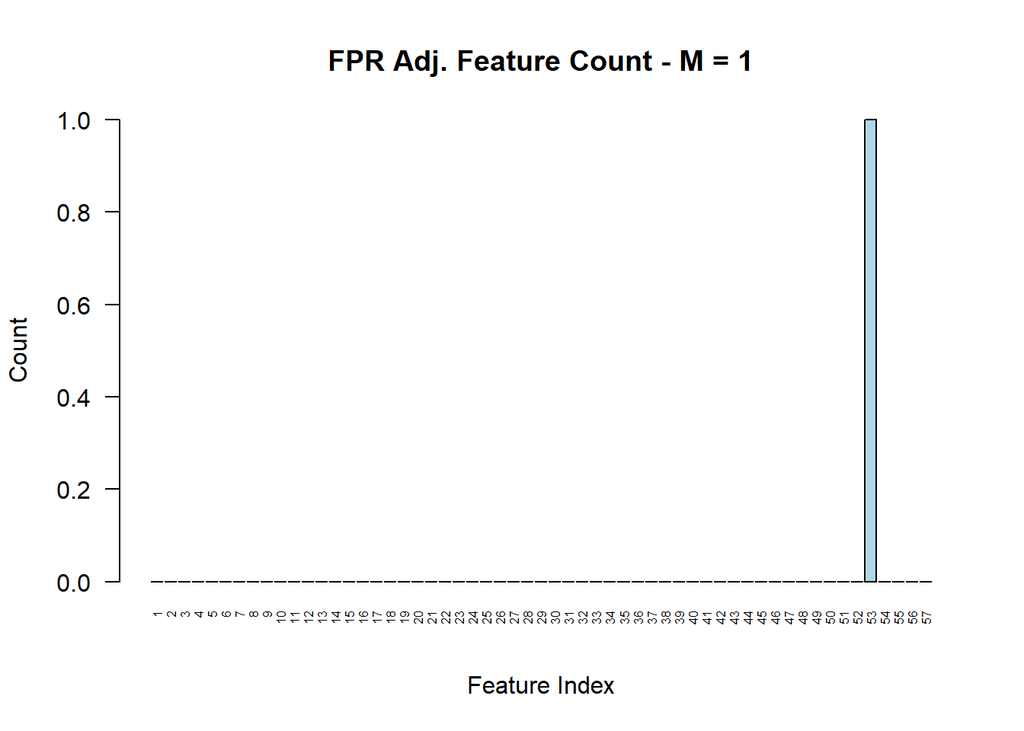

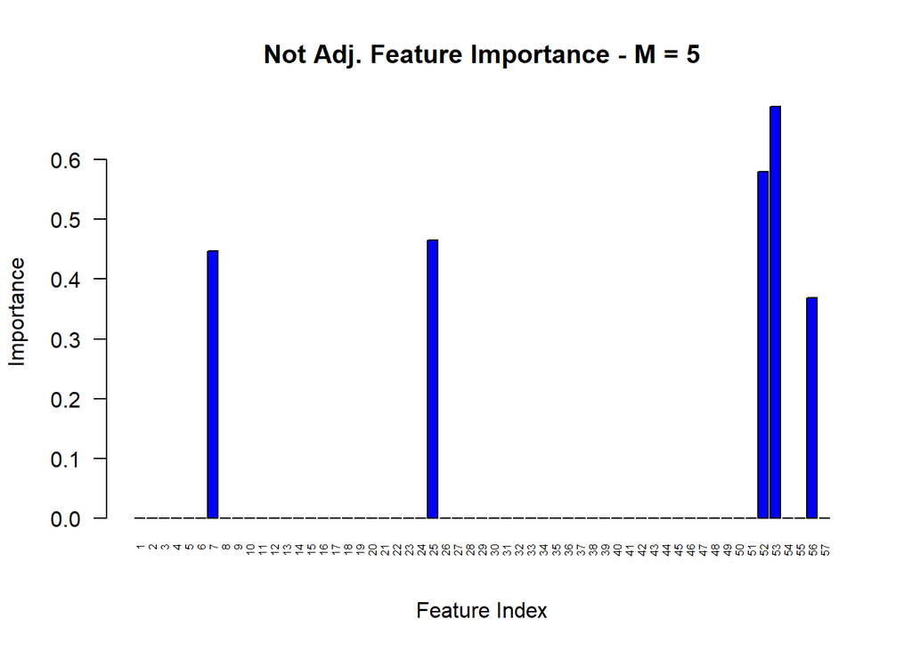

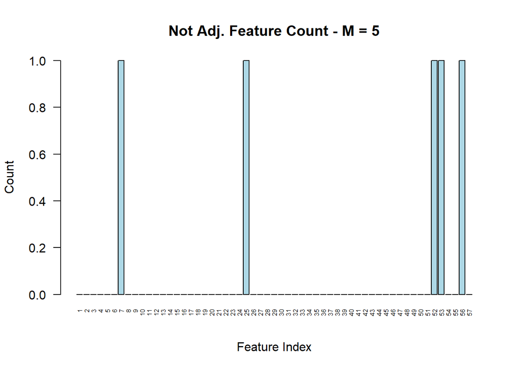

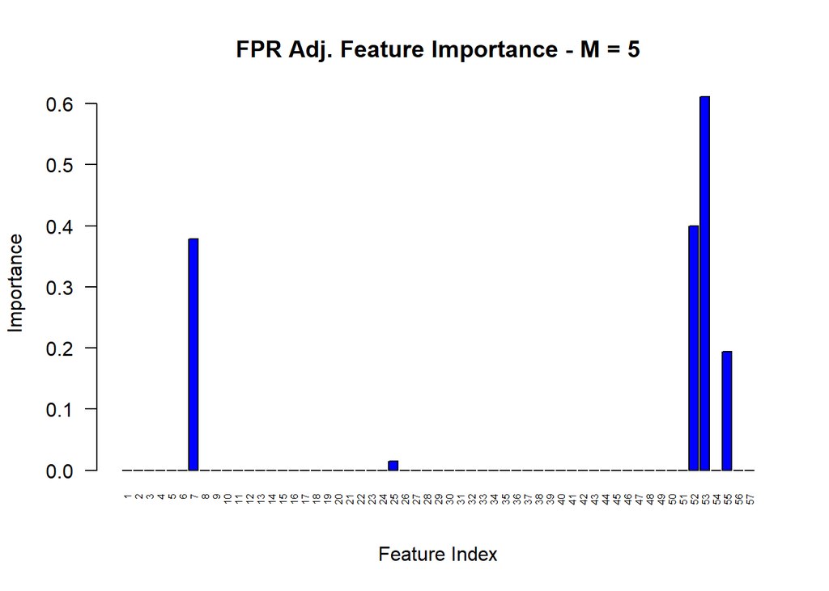

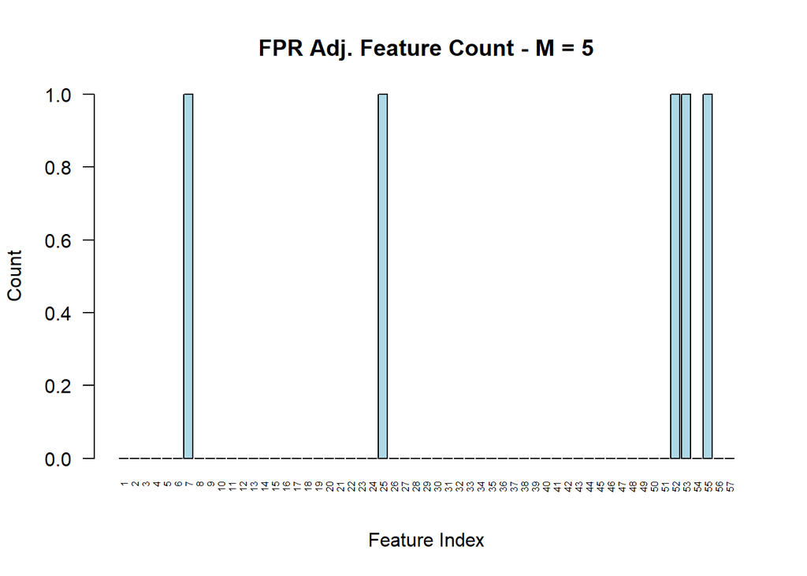

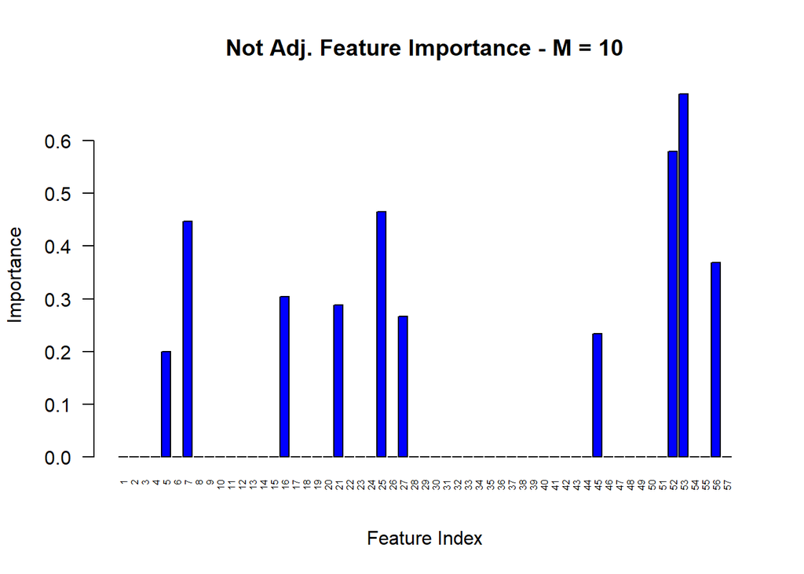

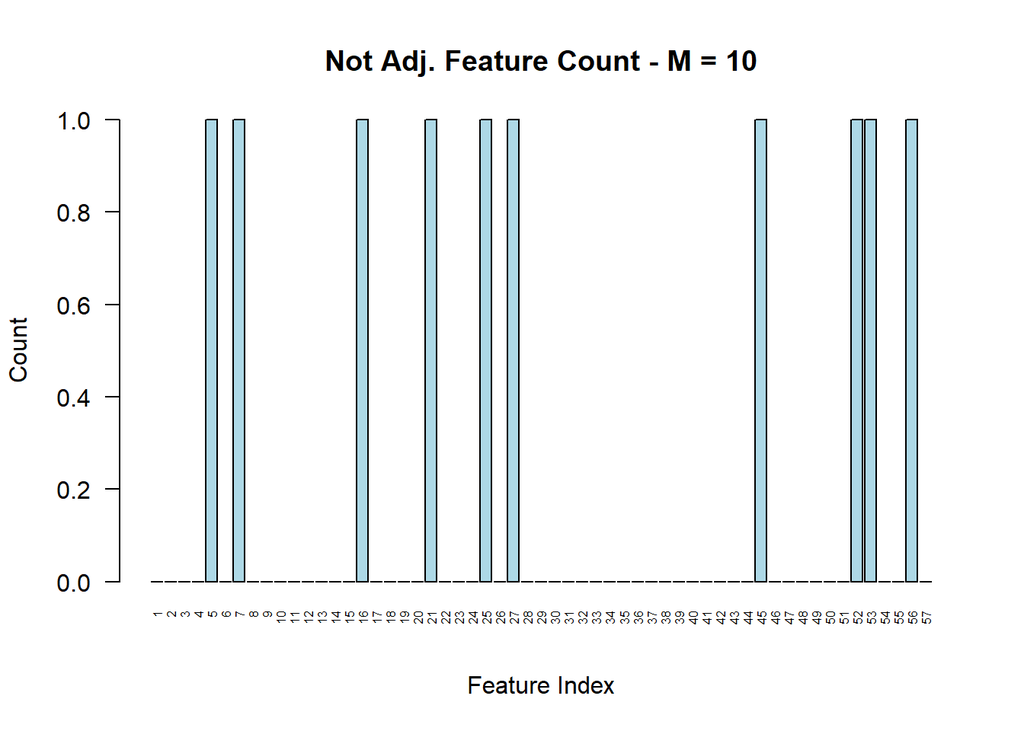

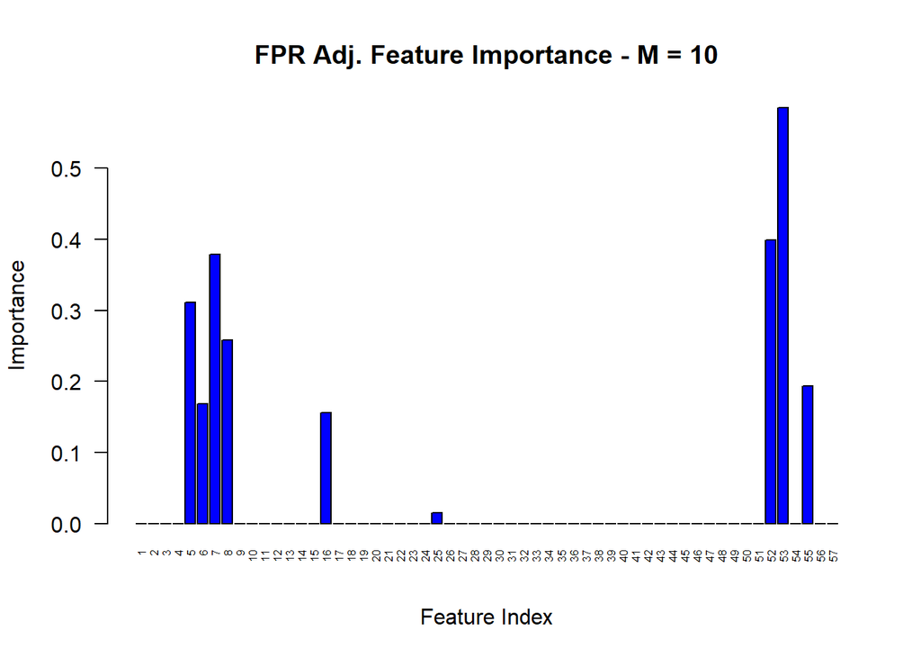

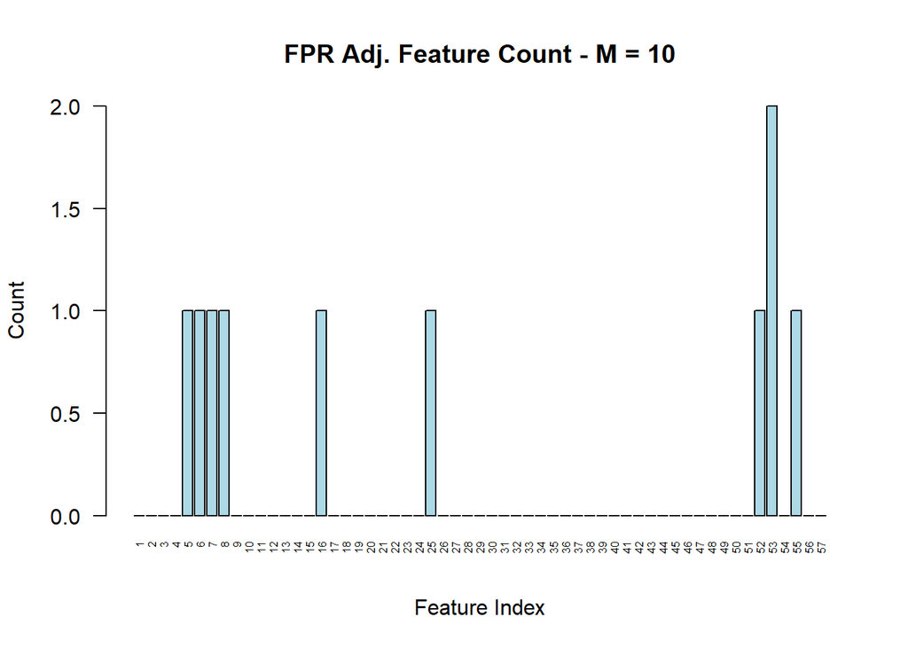

[12 more figures not shown]

```r
# Define function to plot feature importance for a given M
plot_feature_importance <- function(model, M, title_prefix) {
  max_importance <- max(model$feature_importance)
  barplot(model$feature_importance,
          names.arg = 1:length(model$feature_importance),
          las = 2, main = paste(title_prefix, "Feature Importance - M =", M), xlab = "Feature Index",
          ylab = "Importance", col = 'blue', cex.names = 0.5,
          ylim = c(0, max_importance))
}

# Define function to plot feature count for a given M
plot_feature_count <- function(model, M, title_prefix) {
  max_count <- max(model$feature_count)
  barplot(model$feature_count, names.arg = 1:length(model$feature_count), las = 2,
          main = paste(title_prefix, "Feature Count - M =", M), xlab = "Feature Index", ylab = "Count",
          col='lightblue', cex.names=0.5, ylim = c(0, max_count))
}

# Plotting for each specified M value
for(M in M_values) {
  plot_feature_importance(analysis_results_without_fpr$models_list[[as.character(M)]], M, "Not Adj.")

  plot_feature_count(analysis_results_without_fpr$models_list[[as.character(M)]], M, "Not Adj.")

  plot_feature_importance(analysis_results_with_fpr$models_list[[as.character(M)]], M, "FPR Adj.")

  plot_feature_count(analysis_results_with_fpr$models_list[[as.character(M)]], M, "FPR Adj.")
}
```

This analysis shows a clear trend towards the later features, reflected both in high feature importance, contributing significantly to the model’s predictions, as well as count, indicating that the feature was used often to perform splits in the data for classification. More concretely, the standard model put great emphasis on the 52 and 53rd features, which represent the specific character frequencies in the email (potentially unusually characters, like $ or else). Similarly, a considerable role was also played by the final three parameters, representing the average length of uninterrupted sequences of capital letters, the length of the longest length of uninterrupted sequences of capital letters and the total number of capital letters in the email respectively. This also indicated a potential tendency for spam emails to contain capital letters, which is likely to be the case, and seems intuitively correct.

For the adjusted version, we observe a similar count frequency, with a large emphasis on more or less the same final features, namely 52, 53, 55, 56 and 57. Specifically, the model used the feature representing the average length of uninterrupted sequences of capital letters the most. That said, the feature importance showed to be negative for this,indicating a potential reduction in performance, or noise creation when manually adjusting the algorithm for FPR minimization.

Overall, as we don’t have a more precise description of the features, namely the specific words and characters whose frequency is observed, our analysis in this regard remains limited by this.

Finally, while the part hasn’t been included in the final version due to computing time, the results of our analysis on 500 and 1000 iterations yielded additional information for the standard model. While 500 iterations marginally increased performance, the 1000 case showed traces of overfitting, as performance declined. The additional iterations led to no change in the FPR adjusted algorithm.